| Pertemuan 6 dan 7 MPDW |
| --- |
| Materi : “Pendugaan Parameter, Diagnostik Model, dan Peramalan” |

## Packages

```r
library(ggplot2)
library(tsibble)
library(tseries)
library(MASS)
library(forecast)
library(TSA)
library(TTR)
library(aTSA)
library(graphics)
```

## Data Asli

Digunakan data pada pertemuan pertama mengenai harga acuan batubara(USD/ton) setiap bulan (Januari 2013-Agustus 2023)

```r
library(rio)
databara<-import("https://raw.githubusercontent.com/Safwa40/MPDW/main/Data/Data1.csv",header=T)
databara<-databara$`Batubara(USD/ton)`
databara.ts<-ts(databara)
```

### Eksplorasi Data

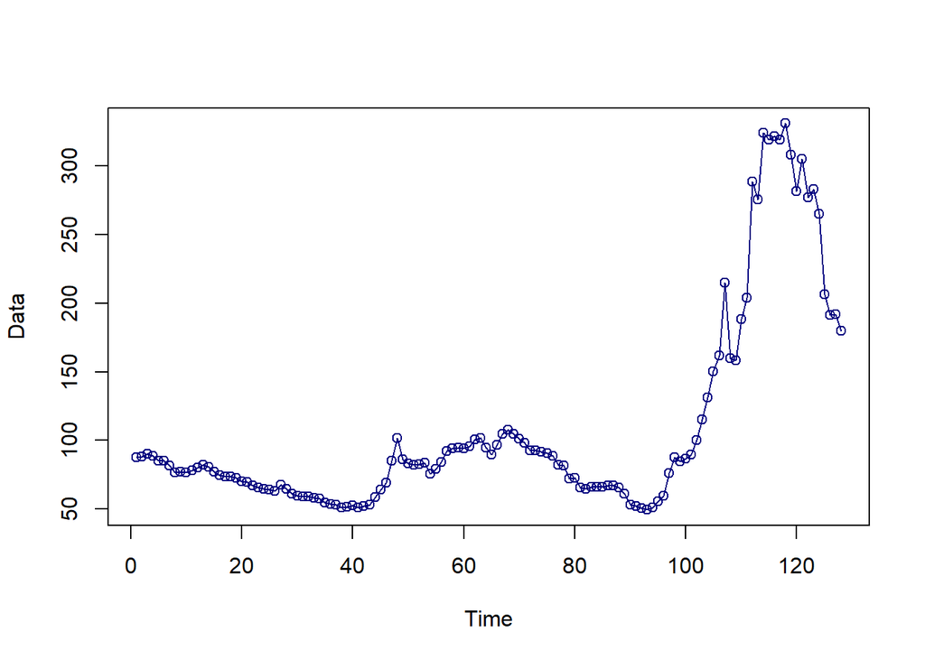

```r
#--PLOT TIME SERIES--#
plot(databara.ts,
     col = "navyblue",
     lwd = 1,
     type = "o",
     xlab = "Time",
     ylab = "Data")
```

Berdasarkan plot data terlihat bahwa data tidak stasioner terhadap rataan dan ragam. Untuk lebih mengetahui tentang data maka akan dilakukan pengecekan acf dan pacf untuk melihat ke stasioneran.

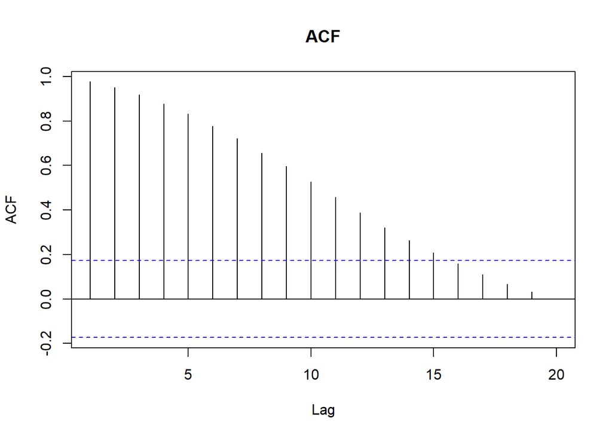

```r
#--CEK KESTASIONERAN---#
acf(databara.ts, main="ACF", lag.max=20)
```

```r
adf.test(databara.ts)
```

```
## Augmented Dickey-Fuller Test
## alternative: stationary
##
## Type 1: no drift no trend
##      lag     ADF p.value
## [1,]   0 -0.0540   0.628
## [2,]   1 -0.0488   0.629
## [3,]   2 -0.3946   0.530
## [4,]   3 -0.5864   0.469
## [5,]   4 -0.2513   0.571
## Type 2: with drift no trend
##      lag    ADF p.value
## [1,]   0 -0.921   0.724
## [2,]   1 -0.908   0.729
## [3,]   2 -1.296   0.593
## [4,]   3 -1.550   0.503
## [5,]   4 -1.210   0.623
## Type 3: with drift and trend
##      lag   ADF p.value
## [1,]   0 -1.65   0.718
## [2,]   1 -1.65   0.719
## [3,]   2 -2.05   0.551
## [4,]   3 -2.31   0.445
## [5,]   4 -2.00   0.574
## ----
## Note: in fact, p.value = 0.01 means p.value <= 0.01
```

```r
#stasioner
```

$H_0$ : Data tidak stasioner dalam rataan

$H_1$ : Data stasioner dalam rataan

Berdasarkan uji ADF tersebut, didapat *p-value* sebesar 0.574 yang lebih besar dari taraf nyata 5% sehingga tak tolak $H_0$ dan menandakan bahwa data tidak stasioner dalam rataan. Hal ini sesuai dengan hasil eksplorasi menggunakan plot time series dan plot ACF.

#### Plot Data Penuh

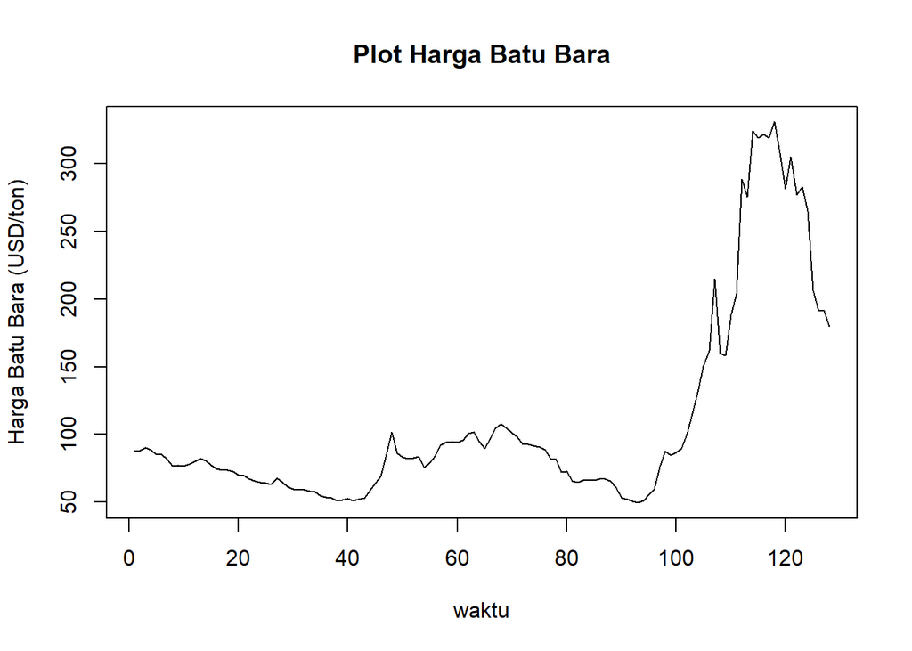

```r
plot.ts(databara.ts, lty=1, xlab="waktu", ylab="Harga Batu Bara (USD/ton)", main="Plot Harga Batu Bara")
```

#### Plot Data Latih

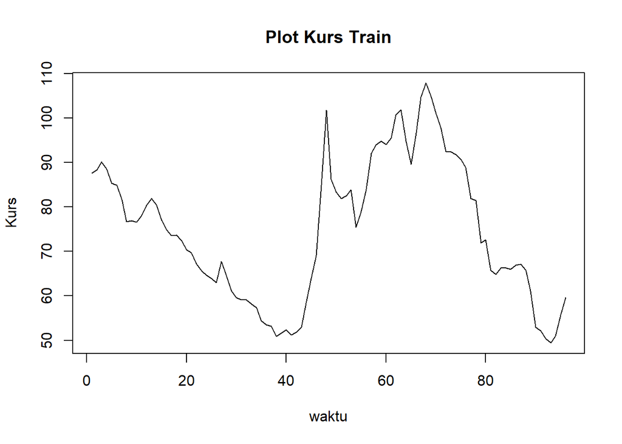

```r
baratrain<-databara[1:96]
train.ts<-ts(baratrain)
plot.ts(train.ts, lty=1, xlab="waktu", ylab="Kurs", main="Plot Kurs Train")
```

#### Plot Data Uji

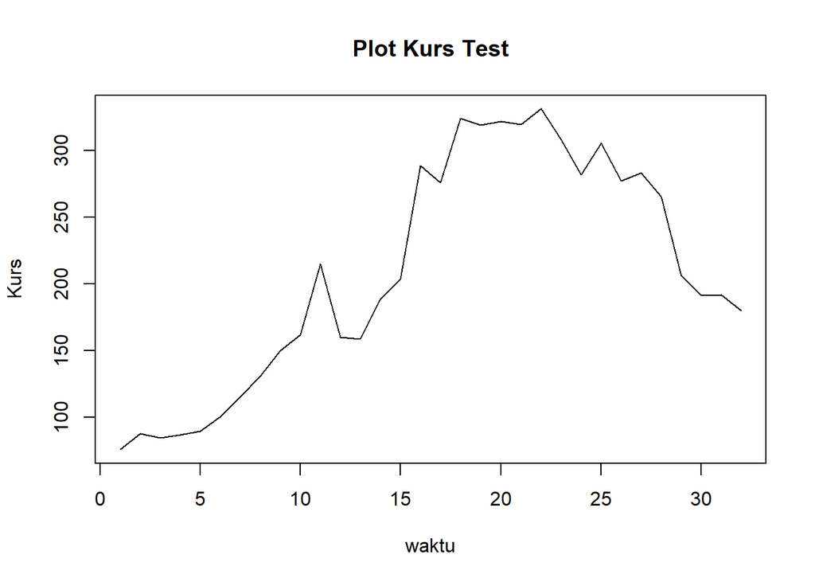

```r
baratest<-databara[97:128]
test.ts<-ts(baratest)
plot.ts(test.ts, lty=1, xlab="waktu", ylab="Kurs", main="Plot Kurs Test")
```

### Uji Stasioneritas Data

#### Plot ACF

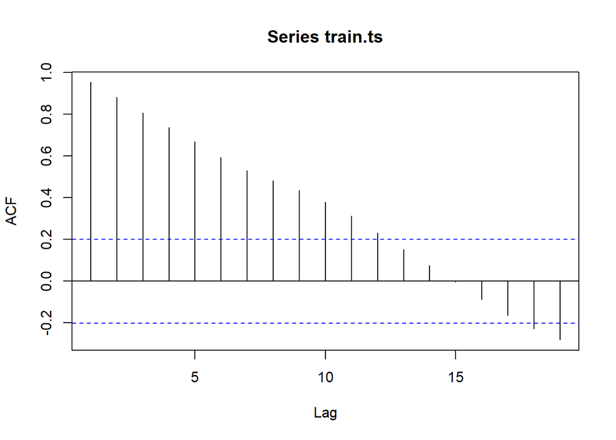

```r
acf(train.ts)
```

Berdasarkan plot ACF, terlihat bahwa plot ACF data menurun secara perlahan (*tails of slowly*). Hal ini juga menjadi indikasi bahwa data tidak stasioner dalam rataan

#### Uji ADF

```r
tseries::adf.test(train.ts)
```

```
##
##  Augmented Dickey-Fuller Test
##
## data:  train.ts
## Dickey-Fuller = -1.652, Lag order = 4, p-value = 0.7203
## alternative hypothesis: stationary
```

$H_0$ : Data tidak stasioner dalam rataan

$H_1$ : Data stasioner dalam rataan

#### Plot Box-Cox

```r
index <- seq(1:96)
bc = boxcox(train.ts~index, lambda = seq(-5,5,by=1))
```

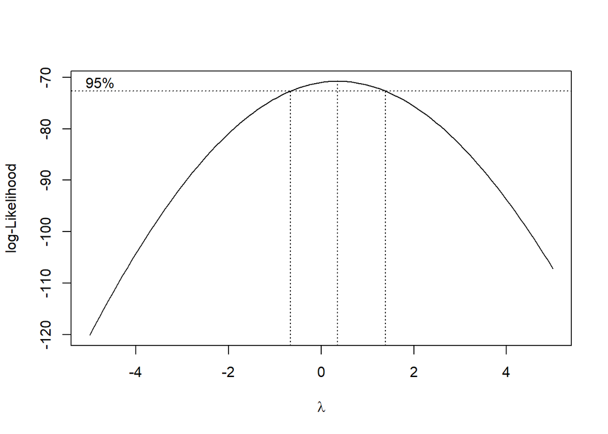

```r
#Nilai Rounded Lambda
lambda <- bc$x[which.max(bc$y)]
lambda
```

```
## [1] 0.3535354
```

```r
#SK
bc$x[bc$y > max(bc$y) - 1/2 * qchisq(.95,1)]
```

```
##  [1] -0.65656566 -0.55555556 -0.45454545 -0.35353535 -0.25252525 -0.15151515
##  [7] -0.05050505  0.05050505  0.15151515  0.25252525  0.35353535  0.45454545
## [13]  0.55555556  0.65656566  0.75757576  0.85858586  0.95959596  1.06060606
## [19]  1.16161616  1.26262626  1.36363636
```

Plot Boxcox menunjukkan nilai *rounded value* ($\lambda$) optimum sebesar **0.3535354** dan pada selang kepercayaan 95% nilai memiliki batas bawah **-0.65656566** dan batas atas **1.36363636**. Selang tersebut memuat nilai satu sehingga dapat dikatakan bahwa data bangkitan stasioner dalam ragam.

### Penanganan Ketidakstasioneran Data

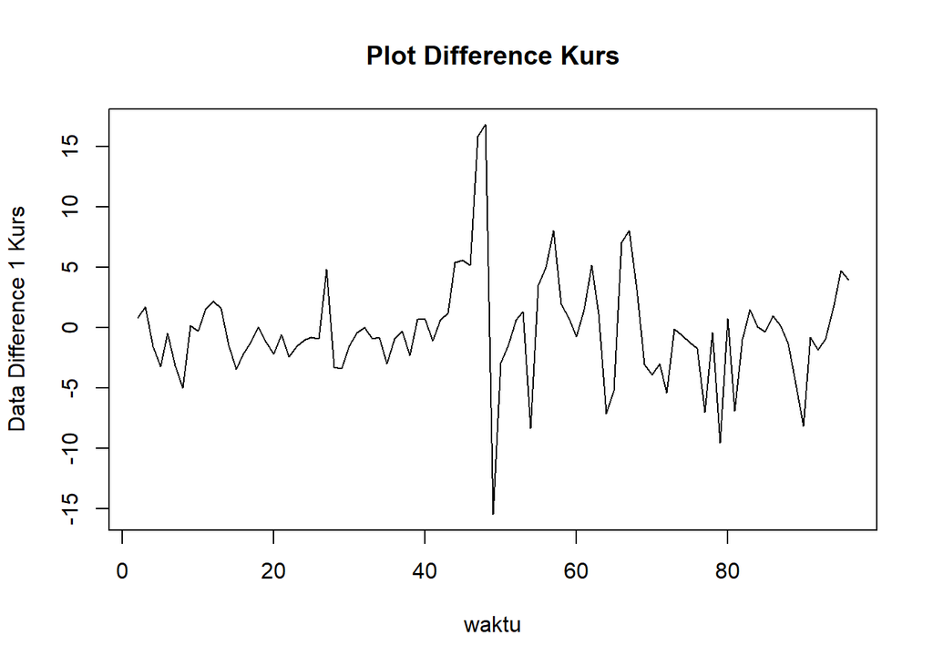

```r
train.diff<-diff(train.ts,differences = 1)
plot.ts(train.diff, lty=1, xlab="waktu", ylab="Data Difference 1 Kurs", main="Plot Difference Kurs")
```

Berdasarkan plot data deret waktu, terlihat bahwa data sudah stasioner dalam rataan ditandai dengan data bergerak pada nilai tengah tertentu (tidak terdapat trend ataupun musiman pada data)

#### Plot ACF

```r
acf(train.diff)
```

[output not shown]

#### Uji ADF

```r
tseries::adf.test(train.diff)
```

```
##
##  Augmented Dickey-Fuller Test
##
## data:  train.diff
## Dickey-Fuller = -3.5904, Lag order = 4, p-value = 0.0381
## alternative hypothesis: stationary
```

$H_0$ : Data tidak stasioner dalam rataan

$H_1$ : Data stasioner dalam rataan

Berdasarkan uji ADF tersebut, didapat *p-value* sebesar 0.0381 yang lebih kecil dari taraf nyata 5% sehingga tolak $H_0$ atau data stasioner dalam rataan. Hal ini sesuai dengan hasil eksplorasi menggunakan plot time series dan plot ACF, sehingga dalam hal ini ketidakstasioneran data sudah berhasil ditangani dan dapat dilanjutkan ke pemodelan

### Identifikasi Model

#### Plot ACF

```r
acf(train.diff)
```

[output not shown]

#### Plot PACF

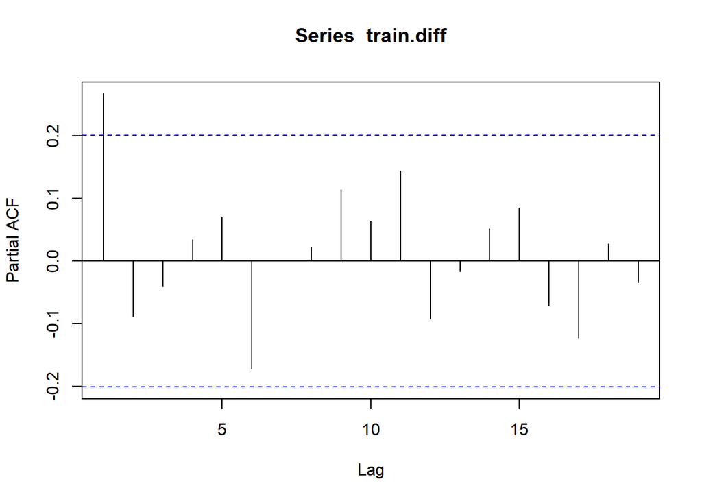

```r
pacf(train.diff)
```

Berdasarkan plot tersebut, terlihat bahwa plot PACF cenderung *cuts off* pada lag ke 1, sehingga jika plot ACF dianggap *tails of*, maka model tentatifnya adalah ARIMA(1,1,0).

Jika baik plot ACF maupun plot PACF keduanya dianggap tails of, maka model yang terbentuk adalah ARIMA(1,1,1)

#### Plot EACF

```r
eacf(train.diff)
```

```
## AR/MA
##   0 1 2 3 4 5 6 7 8 9 10 11 12 13
## 0 x o o o o o o o o o o  o  o  o
## 1 x o o o o o o o o o o  o  o  o
## 2 x x o o o o o o o o o  o  o  o
## 3 x x o o o o o o o o o  o  o  o
## 4 x x o o o o o o o o o  o  o  o
## 5 x x o x x o o o o o o  o  o  o
## 6 o o x x x o o o o o o  o  o  o
## 7 o o x o x o o o o o o  o  o  o
```

Identifikasi model menggunakan plot EACF dilakukan dengan melihat ujung segitiga pada pola segitiga nol. Dalam hal ini model tentatif yang terbentuk adalah ARIMA(0,1,1), ARIMA(0,1,2), ARIMA(1,1,1),ARIMA(1,1,2), ARIMA(2,1,2), dan ARIMA(0,1,3).

### Pendugaan Parameter Model Tentatif

#### ARIMA(0,1,1)

```r
model1.da=Arima(train.diff, order=c(0,1,1),method="ML")
summary(model1.da) #AIC=554.19
```

```
## Series: train.diff
## ARIMA(0,1,1)
##
## Coefficients:
##           ma1
##       -0.9241
## s.e.   0.0723
##
## sigma^2 = 20.19:  log likelihood = -275.09
## AIC=554.19   AICc=554.32   BIC=559.27
##
## Training set error measures:
##                       ME     RMSE      MAE     MPE     MAPE      MASE      ACF1
## Training set -0.01609533 4.446242 2.926669 100.285 238.9568 0.9137335 0.2296965
```

```r
lmtest::coeftest(model1.da) #seluruh parameter signifikan
```

```
##
## z test of coefficients:
##
##      Estimate Std. Error z value  Pr(>|z|)
## ma1 -0.924129   0.072344 -12.774 < 2.2e-16 ***
## ---
## Signif. codes:  0 '***' 0.001 '**' 0.01 '*' 0.05 '.' 0.1 ' ' 1
```

#### ARIMA(0,1,2)

```r
model2.da=Arima(train.diff, order=c(0,1,2),method="ML")
summary(model2.da) #AIC=548.63
```

```
## Series: train.diff
## ARIMA(0,1,2)
##
## Coefficients:
##           ma1      ma2
##       -0.7116  -0.2884
## s.e.   0.1052   0.0965
##
## sigma^2 = 18.4:  log likelihood = -271.32
## AIC=548.63   AICc=548.9   BIC=556.26
##
## Training set error measures:
##                      ME     RMSE      MAE      MPE    MAPE      MASE       ACF1
## Training set 0.07852966 4.221151 2.728046 41.53201 185.711 0.8517216 0.00191555
```

```r
lmtest::coeftest(model2.da) #seluruh parameter signifikan
```

```
##
## z test of coefficients:
##
##      Estimate Std. Error z value  Pr(>|z|)
## ma1 -0.711633   0.105182 -6.7657 1.327e-11 ***
## ma2 -0.288367   0.096508 -2.9880  0.002808 **
## ---
## Signif. codes:  0 '***' 0.001 '**' 0.01 '*' 0.05 '.' 0.1 ' ' 1
```

#### ARIMA(1,1,1)

```r
model3.da=Arima(train.diff, order=c(1,1,1),method="ML")
summary(model3.da) #AIC=548.97
```

```
## Series: train.diff
## ARIMA(1,1,1)
##
## Coefficients:
##          ar1      ma1
##       0.2811  -1.0000
## s.e.  0.1002   0.0384
##
## sigma^2 = 18.49:  log likelihood = -271.48
## AIC=548.97   AICc=549.23   BIC=556.6
##
## Training set error measures:
##                     ME     RMSE      MAE      MPE   MAPE      MASE       ACF1
## Training set 0.0690535 4.232096 2.705836 32.92335 193.09 0.8447874 0.01416895
```

```r
lmtest::coeftest(model3.da) #seluruh parameter signifikan
```

```
##
## z test of coefficients:
##
##      Estimate Std. Error z value  Pr(>|z|)
## ar1  0.281058   0.100164   2.806  0.005017 **
## ma1 -1.000000   0.038394 -26.046 < 2.2e-16 ***
## ---
## Signif. codes:  0 '***' 0.001 '**' 0.01 '*' 0.05 '.' 0.1 ' ' 1
```

#### ARIMA(0,1,3)

```r
model4.da<-Arima(train.diff, order=c(0,1,3),method="ML")
summary(model4.da) #AIC=550.52
```

```
## Series: train.diff
## ARIMA(0,1,3)
##
## Coefficients:
##           ma1      ma2      ma3
##       -0.6993  -0.2616  -0.0391
## s.e.   0.1125   0.1259   0.1172
##
## sigma^2 = 18.59:  log likelihood = -271.26
## AIC=550.52   AICc=550.97   BIC=560.7
##
## Training set error measures:
##                      ME     RMSE      MAE      MPE     MAPE      MASE
## Training set 0.07437707 4.220294 2.713992 32.79349 192.4022 0.8473337
##                      ACF1
## Training set -0.008255836
```

```r
lmtest::coeftest(model4.da) #seluruhhanya 1 parameter signifikan
```

```
##
## z test of coefficients:
##
##     Estimate Std. Error z value  Pr(>|z|)
## ma1 -0.69928    0.11248 -6.2172 5.062e-10 ***
## ma2 -0.26158    0.12594 -2.0771   0.03779 *
## ma3 -0.03914    0.11722 -0.3339   0.73845
## ---
## Signif. codes:  0 '***' 0.001 '**' 0.01 '*' 0.05 '.' 0.1 ' ' 1
```

#### ARIMA(1,1,2)

```r
model5.da=Arima(train.diff, order=c(1,1,2),method="ML")
summary(model5.da) #AIC=550.55
```

```
## Series: train.diff
## ARIMA(1,1,2)
##
## Coefficients:
##          ar1      ma1      ma2
##       0.0955  -0.7978  -0.2022
## s.e.  0.3219   0.3142   0.3116
##
## sigma^2 = 18.6:  log likelihood = -271.28
## AIC=550.55   AICc=551   BIC=560.73
##
## Training set error measures:
##                      ME     RMSE      MAE      MPE     MAPE      MASE
## Training set 0.07519006 4.220739 2.718123 35.92396 190.2637 0.8486236
##                      ACF1
## Training set -0.005699116
```

```r
lmtest::coeftest(model5.da) #hanya 1 parameter signifikan
```

```
##
## z test of coefficients:
##
##      Estimate Std. Error z value Pr(>|z|)
## ar1  0.095507   0.321887  0.2967  0.76669
## ma1 -0.797787   0.314236 -2.5388  0.01112 *
## ma2 -0.202157   0.311570 -0.6488  0.51645
## ---
## Signif. codes:  0 '***' 0.001 '**' 0.01 '*' 0.05 '.' 0.1 ' ' 1
```

#### ARIMA(2,1,2)

```r
model6.da=Arima(train.diff, order=c(2,1,2),method="ML")
summary(model6.da) #AIC=551.15
```

```
## Series: train.diff
## ARIMA(2,1,2)
##
## Coefficients:
##           ar1     ar2      ma1      ma2
##       -0.6425  0.2188  -0.0436  -0.9564
## s.e.   0.1389  0.1174   0.1020   0.1014
##
## sigma^2 = 18.49:  log likelihood = -270.57
## AIC=551.15   AICc=551.83   BIC=563.86
##
## Training set error measures:
##                      ME     RMSE      MAE      MPE     MAPE      MASE
## Training set 0.07566792 4.185549 2.727212 106.4742 206.7058 0.8514611
##                      ACF1
## Training set 0.0007680721
```

```r
lmtest::coeftest(model6.da) #hanya 2 parameter signifikan
```

```
##
## z test of coefficients:
##
##      Estimate Std. Error z value  Pr(>|z|)
## ar1 -0.642486   0.138903 -4.6254 3.738e-06 ***
## ar2  0.218820   0.117407  1.8638   0.06235 .
## ma1 -0.043586   0.102042 -0.4271   0.66928
## ma2 -0.956413   0.101388 -9.4332 < 2.2e-16 ***
## ---
## Signif. codes:  0 '***' 0.001 '**' 0.01 '*' 0.05 '.' 0.1 ' ' 1
```

Berdasarkan pendugaan parameter di atas, nilai AIC terkecil dimiliki oleh model ARIMA(0,1,2) dan parameter model ARIMA(0,1,2) juga seluruhnya signifikan sehingga model yang dipilih adalah model ARIMA(0,1,2).

### Analisis Sisaan

Model terbaik hasil identifikasi kemudian dicek asumsi sisaannya. Sisaan model ARIMA harus memenuhi asumsi normalitas, kebebasan sisaan, dan kehomogenan ragam. Diagnostik model dilakukan secara eksplorasi dan uji formal.

#### Eksplorasi Sisaan

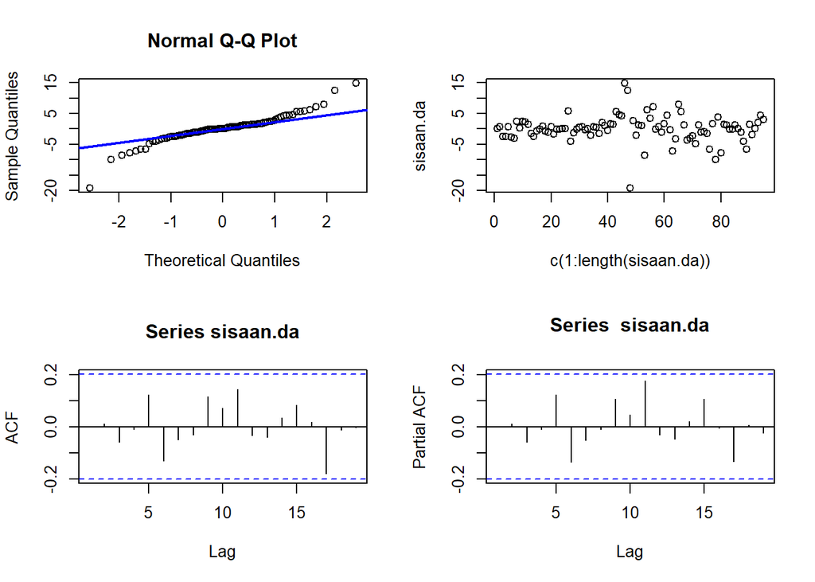

```r
#Eksplorasi
sisaan.da <- model2.da$residuals
par(mfrow=c(2,2))
qqnorm(sisaan.da)
qqline(sisaan.da, col = "blue", lwd = 2)
plot(c(1:length(sisaan.da)),sisaan.da)
acf(sisaan.da)
pacf(sisaan.da)
```

```r
par(mfrow = c(1,1))
```

Berdasarkan plot kuantil-kuantil normal, secara eksplorasi ditunjukkan sisaan tidak menyebar normal ditandai dengan titik titik yang cenderung tidak mengikuti garis $45^{\circ}$. Kemudian dapat dilihat juga lebar pita sisaan yang cenderung tidak sama menandakan bahwa sisaan memiliki ragam yang heterogen. Plot ACF dan PACF sisaan ARIMA(0,1,2) juga tidak signifikan pada 20 lag awal yang menandakan saling bebas. Kondisi ini akan diuji lebih lanjut dengan uji formal.

#### Uji Formal

```r
#1) Sisaan Menyebar Normal
ks.test(sisaan.da,"pnorm")
```

```
##
##  Exact one-sample Kolmogorov-Smirnov test
##
## data:  sisaan.da
## D = 0.23754, p-value = 3.358e-05
## alternative hypothesis: two-sided
```

Selain dengan eksplorasi, asumsi tersebut dapat diuji menggunakan uji formal. Pada tahapan ini uji formal yang digunakan untuk normalitas adalah uji Kolmogorov-Smirnov (KS). Hipotesis pada uji KS adalah sebagai berikut.

$H_0$ : Sisaan menyebar normal

$H_1$ : Sisaan tidak menyebar normal

Berdasarkan uji KS tersebut, didapat *p-value* sebesar 0.00 yang kurang dari taraf nyata 5% sehingga tolak $H_0$ dan menandakan bahwa sisaan tidak menyebar normal. Hal ini sesuai dengan hasil eksplorasi menggunakan plot kuantil-kuantil normal.

```r
#2) Sisaan saling bebas/tidak ada autokorelasi
Box.test(sisaan.da, type = "Ljung")
```

```
##
##  Box-Ljung test
##
## data:  sisaan.da
## X-squared = 0.00035971, df = 1, p-value = 0.9849
```

Selanjutnya akan dilakukan uji formal untuk kebebasan sisaan menggunakan uji Ljung-Box. Hipotesis yang digunakan adalah sebagai berikut.

$H_0$ : Sisaan saling bebas

$H_1$ : Sisaan tidak tidak saling bebas

```r
#3) Sisaan homogen
Box.test((sisaan.da)^2, type = "Ljung")
```

```
##
##  Box-Ljung test
##
## data:  (sisaan.da)^2
## X-squared = 13.402, df = 1, p-value = 0.0002513
```

Hipotesis yang digunakan untuk uji kehomogenan ragam adalah sebagai berikut.

$H_0$ : Ragam sisaan homogen

$H_1$ : Ragam sisaan tidak homogen

```r
#4) Nilai tengah sisaan sama dengan nol
t.test(sisaan.da, mu = 0, conf.level = 0.95)  #tak tolak h0 > nilai tengah sisaan sama dengan 0
```

```
##
##  One Sample t-test
##
## data:  sisaan.da
## t = 0.1804, df = 94, p-value = 0.8572
## alternative hypothesis: true mean is not equal to 0
## 95 percent confidence interval:
##  -0.7857750  0.9428343
## sample estimates:
##  mean of x
## 0.07852966
```

Terakhir, dengan uji-t, akan dicek apakah nilai tengah sisaan sama dengan nol. Hipotesis yang diujikan sebagai berikut.

$H_0$ : nilai tengah sisaan sama dengan 0

$H_1$ : nilai tengah sisaan tidak sama dengan 0

Berdasarkan uji-ttersebut, didapat *p-value* sebesar 0.8572 yang lebih besar dari taraf nyata 5% sehingga tak tolak $H_0$ dan menandakan bahwa nilai tengah sisaan sama dengan nol. Hal ini sesuai dengan eksplorasi.

### Overfitting

Tahapan selanjutnya adalah *overfitting* dilakukan dengan menaikkan orde AR(p) dan MA(q) dari model ARIMA(0,1,2) untuk melihat apakah terdapat model lain yang lebih baik dari model saat ini. Kandidat model *overfitting* adalah ARIMA(1,1,2) dan ARIMA(0,1,3).

```r
#---OVERFITTING---#
model1a.ma2=Arima(train.diff, order=c(1,1,2),method="ML")
summary(model1a.ma2) #550.55
```

```
## Series: train.diff
## ARIMA(1,1,2)
##
## Coefficients:
##          ar1      ma1      ma2
##       0.0955  -0.7978  -0.2022
## s.e.  0.3219   0.3142   0.3116
##
## sigma^2 = 18.6:  log likelihood = -271.28
## AIC=550.55   AICc=551   BIC=560.73
##
## Training set error measures:
##                      ME     RMSE      MAE      MPE     MAPE      MASE
## Training set 0.07519006 4.220739 2.718123 35.92396 190.2637 0.8486236
##                      ACF1
## Training set -0.005699116
```

```r
lmtest::coeftest(model1a.ma2) #ar1 dan ma2 tidak signifikan
```

```
##
## z test of coefficients:
##
##      Estimate Std. Error z value Pr(>|z|)
## ar1  0.095507   0.321887  0.2967  0.76669
## ma1 -0.797787   0.314236 -2.5388  0.01112 *
## ma2 -0.202157   0.311570 -0.6488  0.51645
## ---
## Signif. codes:  0 '***' 0.001 '**' 0.01 '*' 0.05 '.' 0.1 ' ' 1
```

```r
model1b.ma2=Arima(train.diff, order=c(0,1,3),method="ML")
summary(model1b.ma2) #550.52
```

```
## Series: train.diff
## ARIMA(0,1,3)
##
## Coefficients:
##           ma1      ma2      ma3
##       -0.6993  -0.2616  -0.0391
## s.e.   0.1125   0.1259   0.1172
##
## sigma^2 = 18.59:  log likelihood = -271.26
## AIC=550.52   AICc=550.97   BIC=560.7
##
## Training set error measures:
##                      ME     RMSE      MAE      MPE     MAPE      MASE
## Training set 0.07437707 4.220294 2.713992 32.79349 192.4022 0.8473337
##                      ACF1
## Training set -0.008255836
```

```r
lmtest::coeftest(model1b.ma2) #ma3 tidak signifikan
```

```
##
## z test of coefficients:
##
##     Estimate Std. Error z value  Pr(>|z|)
## ma1 -0.69928    0.11248 -6.2172 5.062e-10 ***
## ma2 -0.26158    0.12594 -2.0771   0.03779 *
## ma3 -0.03914    0.11722 -0.3339   0.73845
## ---
## Signif. codes:  0 '***' 0.001 '**' 0.01 '*' 0.05 '.' 0.1 ' ' 1
```

```r
#model yang dipilih adalah model awal, yaitu ARIMA(0,1,2)
```

Berdasarkan kedua model hasil *overfitting* di atas, model AARIMA(1,1,2) dan ARIMA(0,1,3) memiliki AIC yang lebih besar dibandingkan dengan model ARIMA(0,1,2) dan parameter kedua model ARIMA(1,1,2) dan ARIMA(0,1,3) tidak seluruhnya signifikan. Oleh karena itu, model ARIMA(0,1,2) akan tetap digunakan untuk melakukan peramalan.

### Peramalan

Peramalan dilakukan menggunakan fungsi `forecast()` . Contoh peramalan berikut ini dilakukan untuk 30 hari ke depan.

```r
#---FORECAST---#
ramalan.da <- forecast::forecast(model2.da, h = 30)
ramalan.da
```

```
##     Point Forecast     Lo 80    Hi 80     Lo 95    Hi 95
##  97      0.5645325 -4.961304 6.090369 -7.886505 9.015570
##  98     -0.2833368 -6.050191 5.483517 -9.102979 8.536305
##  99     -0.2833368 -6.050191 5.483517 -9.102979 8.536305
## 100     -0.2833368 -6.050191 5.483517 -9.102979 8.536305
## 101     -0.2833368 -6.050191 5.483517 -9.102979 8.536305
## 102     -0.2833368 -6.050191 5.483517 -9.102979 8.536305
## 103     -0.2833368 -6.050191 5.483517 -9.102979 8.536305
## 104     -0.2833368 -6.050191 5.483517 -9.102979 8.536305
## 105     -0.2833368 -6.050191 5.483517 -9.102979 8.536305
## 106     -0.2833368 -6.050191 5.483517 -9.102979 8.536305
## 107     -0.2833368 -6.050191 5.483517 -9.102979 8.536305
## 108     -0.2833368 -6.050191 5.483517 -9.102979 8.536305
## 109     -0.2833368 -6.050191 5.483517 -9.102979 8.536305
## 110     -0.2833368 -6.050191 5.483517 -9.102979 8.536305
```

[output cut: 16 more lines]

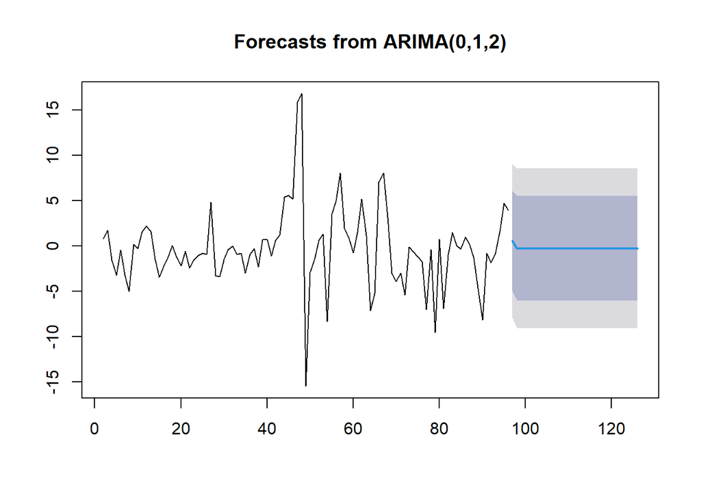

```r
data.ramalan.da <- ramalan.da$mean
plot(ramalan.da)
```

Berdasarkan hasil plot ramalan di atas, dapat dilihat bahwa ramalan ARIMA(0,1,2) cenderung stabil hingga akhir periode. Selanjutnya, dapat dicari nilai akurasi antara hasil ramalan dengan data uji sebagai berikut.

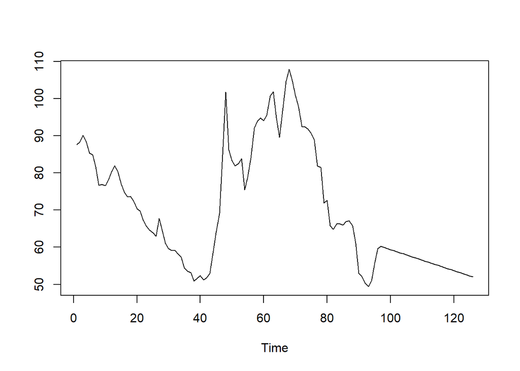

```r
pt_1 <- train.ts[96] #nilai akhir data latih
hasil.forc.Diff <- data.ramalan.da
hasil <- diffinv(hasil.forc.Diff, differences = 1) + pt_1
#has.1 sama hasilnta dengan: cumsum(c(pt_1,hasil.forc.Diff))
ts.plot(train.ts,hasil)
```

```r
perbandingan.da<-matrix(data=c(head(test.ts, n=30), hasil[-1]),
                     nrow = 30, ncol = 2)
colnames(perbandingan.da)<-c("Aktual","Hasil Forecast")
perbandingan.da
```

```
##       Aktual Hasil Forecast
##  [1,]  75.84       60.21453
##  [2,]  87.79       59.93120
##  [3,]  84.47       59.64786
##  [4,]  86.68       59.36452
##  [5,]  89.74       59.08119
##  [6,] 100.33       58.79785
##  [7,] 115.35       58.51451
##  [8,] 130.99       58.23117
##  [9,] 150.03       57.94784
## [10,] 161.63       57.66450
## [11,] 215.01       57.38116
## [12,] 159.79       57.09783
## [13,] 158.50       56.81449
## [14,] 188.38       56.53115
```

[output cut: 16 more lines]

```r
accuracy(ts(hasil[-1]), head(test.ts, n=30))
```

```
##                ME     RMSE      MAE      MPE     MAPE      ACF1 Theil's U
## Test set 154.0489 178.0456 154.0489 65.82004 65.82004 0.9075129  4.975018
```

Dari data tersebut terlihat nilai mape >10 menandakan data tersebut kurang bagus

| Pertemuan 6 dan 7 MPDW |
| --- |
| Materi : “Pendugaan Parameter, Diagnostik Model, dan Peramalan” |

## Packages

```r
library(ggplot2)
library(tsibble)
library(tseries)
library(MASS)
library(forecast)
library(TSA)
library(TTR)
library(aTSA)
library(graphics)
```

## Data Asli

Digunakan data pada pertemuan pertama mengenai harga acuan batubara(USD/ton) setiap bulan (Januari 2013-Agustus 2023)

```r
library(rio)
databara<-import("https://raw.githubusercontent.com/Safwa40/MPDW/main/Data/Data1.csv",header=T)
databara<-databara$`Batubara(USD/ton)`
databara.ts<-ts(databara)
```

### Eksplorasi Data

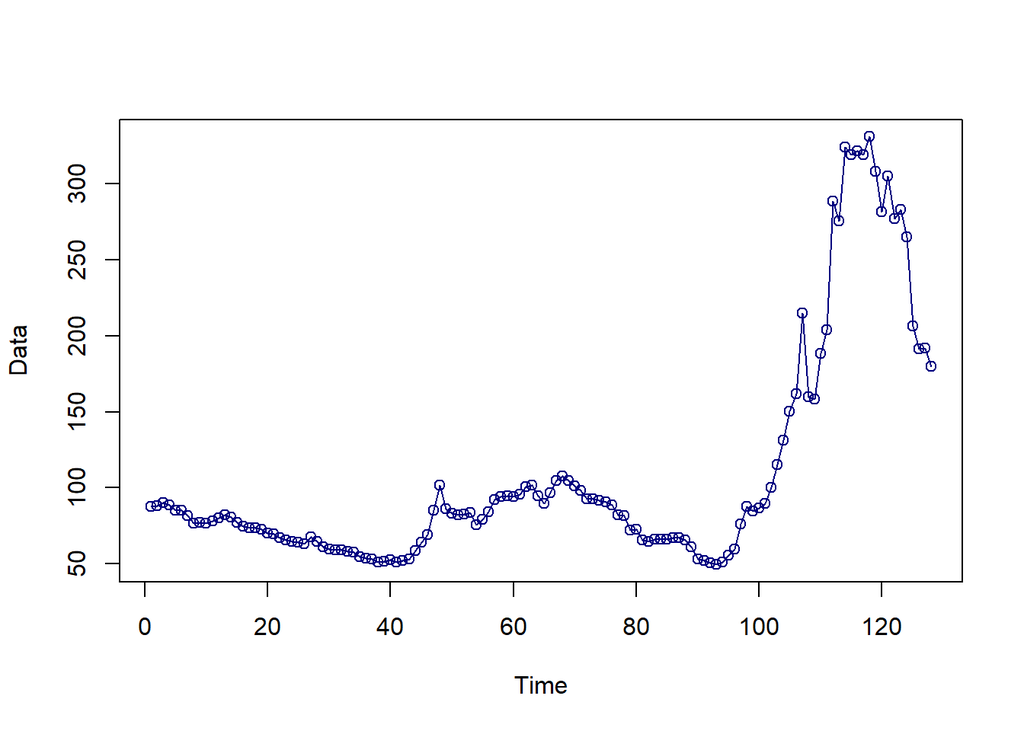

```r
#--PLOT TIME SERIES--#
plot(databara.ts,
     col = "navyblue",
     lwd = 1,
     type = "o",
     xlab = "Time",
     ylab = "Data")
```

Berdasarkan plot data terlihat bahwa data tidak stasioner terhadap rataan dan ragam. Untuk lebih mengetahui tentang data maka akan dilakukan pengecekan acf dan pacf untuk melihat ke stasioneran.

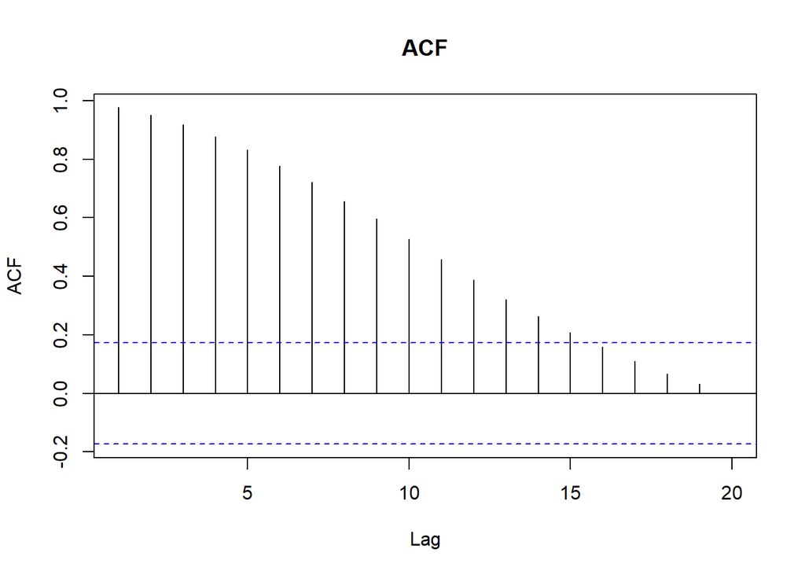

```r
#--CEK KESTASIONERAN---#
acf(databara.ts, main="ACF", lag.max=20)
```

```r
adf.test(databara.ts)
```

```
## Augmented Dickey-Fuller Test
## alternative: stationary
##
## Type 1: no drift no trend
##      lag     ADF p.value
## [1,]   0 -0.0540   0.628
## [2,]   1 -0.0488   0.629
## [3,]   2 -0.3946   0.530
## [4,]   3 -0.5864   0.469
## [5,]   4 -0.2513   0.571
## Type 2: with drift no trend
##      lag    ADF p.value
## [1,]   0 -0.921   0.724
## [2,]   1 -0.908   0.729
## [3,]   2 -1.296   0.593
## [4,]   3 -1.550   0.503
## [5,]   4 -1.210   0.623
## Type 3: with drift and trend
##      lag   ADF p.value
## [1,]   0 -1.65   0.718
## [2,]   1 -1.65   0.719
## [3,]   2 -2.05   0.551
## [4,]   3 -2.31   0.445
## [5,]   4 -2.00   0.574
## ----
## Note: in fact, p.value = 0.01 means p.value <= 0.01
```

```r
#stasioner
```

$H_0$ : Data tidak stasioner dalam rataan

$H_1$ : Data stasioner dalam rataan

Berdasarkan uji ADF tersebut, didapat *p-value* sebesar 0.574 yang lebih besar dari taraf nyata 5% sehingga tak tolak $H_0$ dan menandakan bahwa data tidak stasioner dalam rataan. Hal ini sesuai dengan hasil eksplorasi menggunakan plot time series dan plot ACF.

#### Plot Data Penuh

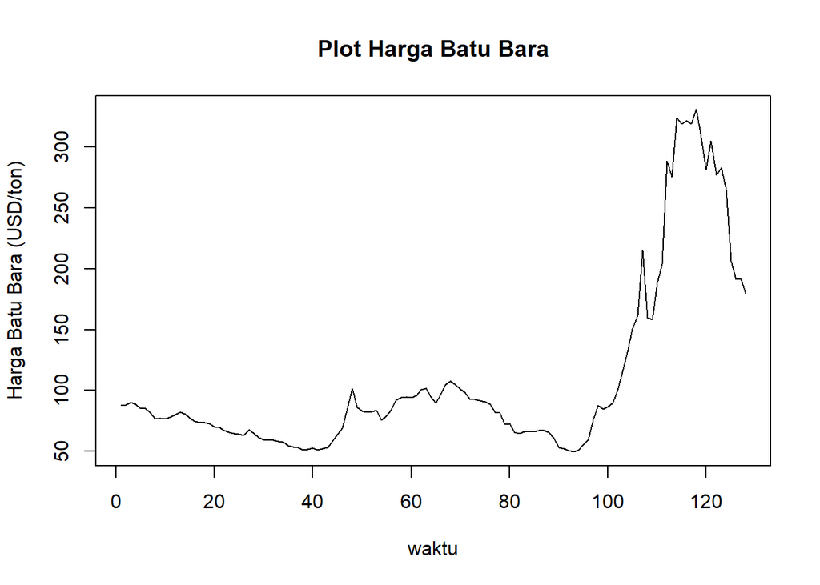

```r
plot.ts(databara.ts, lty=1, xlab="waktu", ylab="Harga Batu Bara (USD/ton)", main="Plot Harga Batu Bara")
```

#### Plot Data Latih

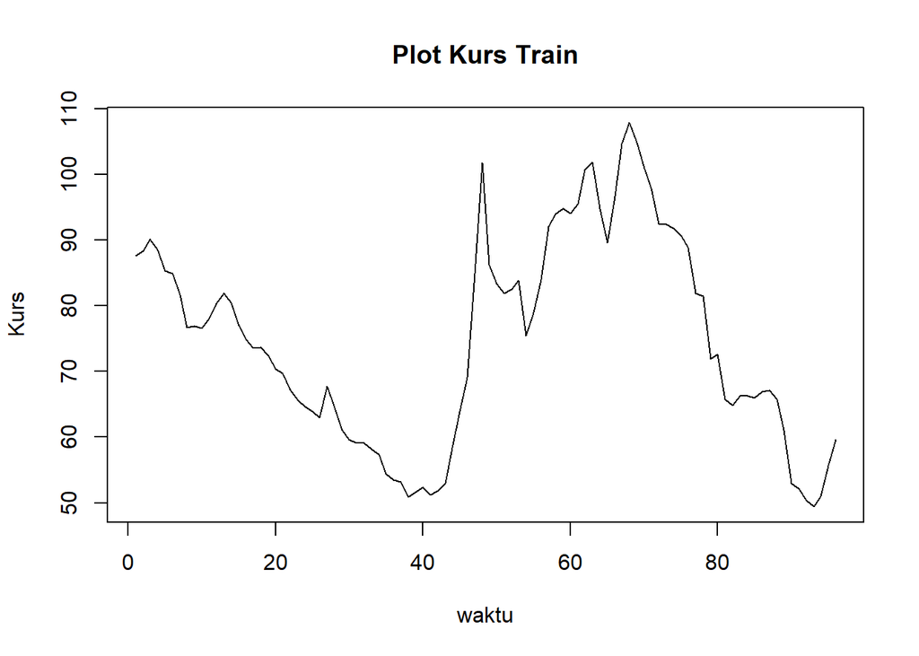

```r
baratrain<-databara[1:96]
train.ts<-ts(baratrain)
plot.ts(train.ts, lty=1, xlab="waktu", ylab="Kurs", main="Plot Kurs Train")
```

#### Plot Data Uji

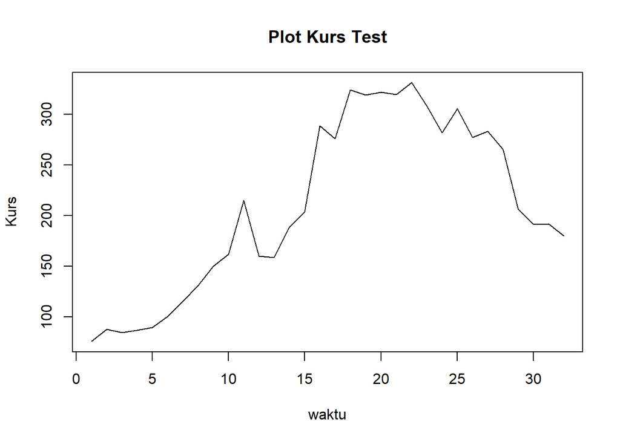

```r
baratest<-databara[97:128]
test.ts<-ts(baratest)
plot.ts(test.ts, lty=1, xlab="waktu", ylab="Kurs", main="Plot Kurs Test")
```

### Uji Stasioneritas Data

#### Plot ACF

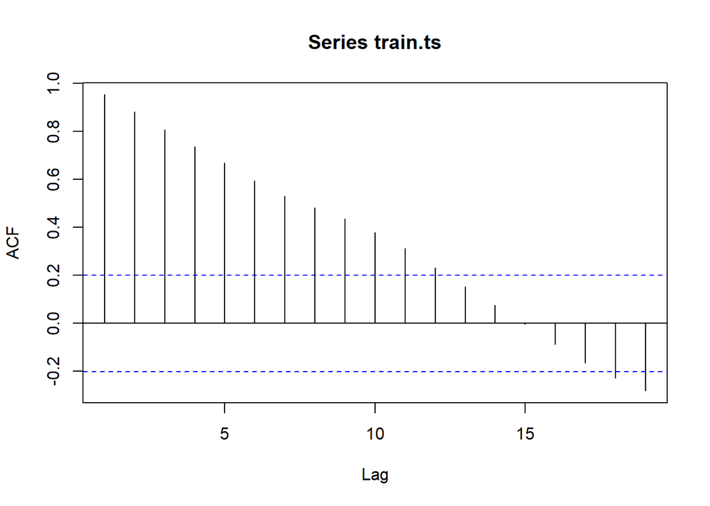

```r
acf(train.ts)
```

Berdasarkan plot ACF, terlihat bahwa plot ACF data menurun secara perlahan (*tails of slowly*). Hal ini juga menjadi indikasi bahwa data tidak stasioner dalam rataan

#### Uji ADF

```r
tseries::adf.test(train.ts)
```

```
##
##  Augmented Dickey-Fuller Test
##
## data:  train.ts
## Dickey-Fuller = -1.652, Lag order = 4, p-value = 0.7203
## alternative hypothesis: stationary
```

$H_0$ : Data tidak stasioner dalam rataan

$H_1$ : Data stasioner dalam rataan

#### Plot Box-Cox

```r
index <- seq(1:96)
bc = boxcox(train.ts~index, lambda = seq(-5,5,by=1))
```

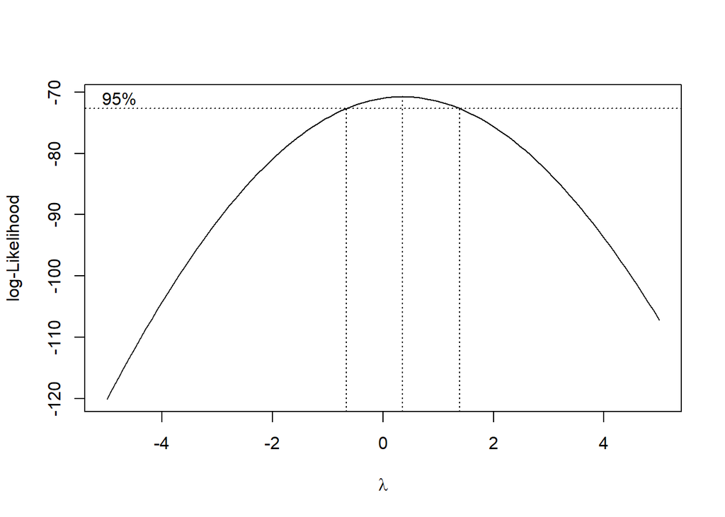

```r
#Nilai Rounded Lambda
lambda <- bc$x[which.max(bc$y)]
lambda
```

```
## [1] 0.3535354
```

```r
#SK
bc$x[bc$y > max(bc$y) - 1/2 * qchisq(.95,1)]
```

```
##  [1] -0.65656566 -0.55555556 -0.45454545 -0.35353535 -0.25252525 -0.15151515
##  [7] -0.05050505  0.05050505  0.15151515  0.25252525  0.35353535  0.45454545
## [13]  0.55555556  0.65656566  0.75757576  0.85858586  0.95959596  1.06060606
## [19]  1.16161616  1.26262626  1.36363636
```

Plot Boxcox menunjukkan nilai *rounded value* ($\lambda$) optimum sebesar **0.3535354** dan pada selang kepercayaan 95% nilai memiliki batas bawah **-0.65656566** dan batas atas **1.36363636**. Selang tersebut memuat nilai satu sehingga dapat dikatakan bahwa data bangkitan stasioner dalam ragam.

### Penanganan Ketidakstasioneran Data

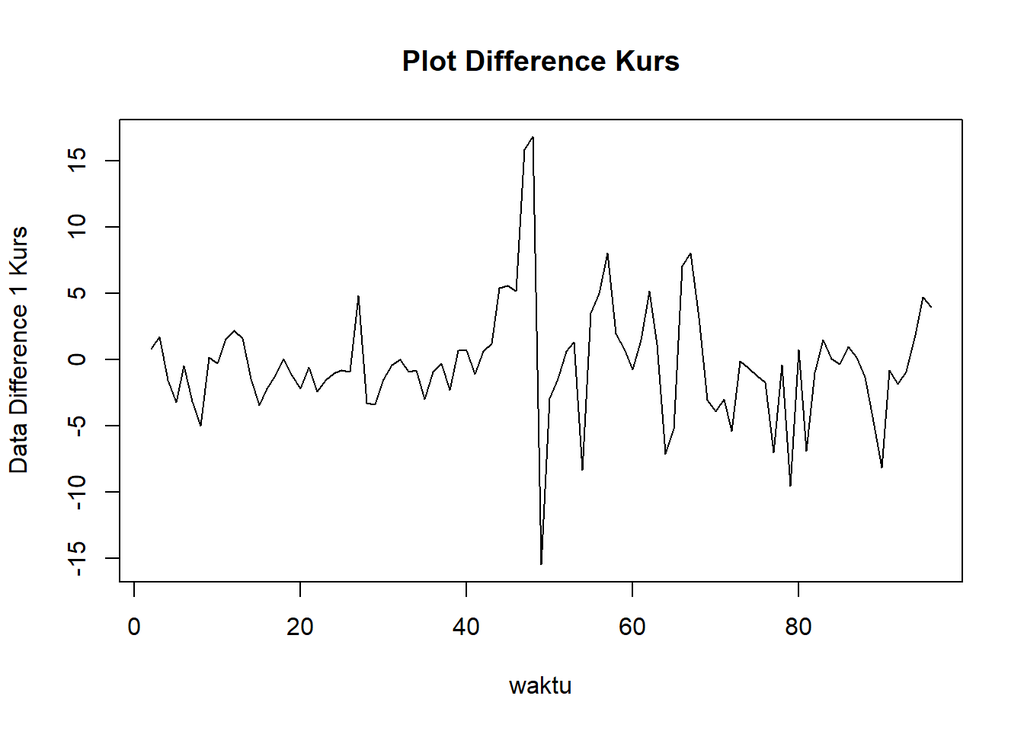

```r
train.diff<-diff(train.ts,differences = 1)
plot.ts(train.diff, lty=1, xlab="waktu", ylab="Data Difference 1 Kurs", main="Plot Difference Kurs")
```

Berdasarkan plot data deret waktu, terlihat bahwa data sudah stasioner dalam rataan ditandai dengan data bergerak pada nilai tengah tertentu (tidak terdapat trend ataupun musiman pada data)

#### Plot ACF

```r
acf(train.diff)
```

[output not shown]

Berdasarkan plot tersebut, terlihat bahwa plot ACF cuts off pada lag ke 1. Hal ini menandakan data sudah stasioner dalam rataan dan ketidakstasioneran data telah berhasil tertangani.

#### Uji ADF

```r
tseries::adf.test(train.diff)
```

```
##
##  Augmented Dickey-Fuller Test
##
## data:  train.diff
## Dickey-Fuller = -3.5904, Lag order = 4, p-value = 0.0381
## alternative hypothesis: stationary
```

$H_0$ : Data tidak stasioner dalam rataan

$H_1$ : Data stasioner dalam rataan

Berdasarkan uji ADF tersebut, didapat *p-value* sebesar 0.0381 yang lebih kecil dari taraf nyata 5% sehingga tolak $H_0$ atau data stasioner dalam rataan. Hal ini sesuai dengan hasil eksplorasi menggunakan plot time series dan plot ACF, sehingga dalam hal ini ketidakstasioneran data sudah berhasil ditangani dan dapat dilanjutkan ke pemodelan

### Identifikasi Model

#### Plot ACF

```r
acf(train.diff)
```

[output not shown]

Berdasarkan plot tersebut, terlihat bahwa plot ACF cenderung *cuts off* pada lag ke 1, sehingga jika plot PACF dianggap *tails of*, maka model tentatifnya adalah ARIMA(0,1,1).

#### Plot PACF

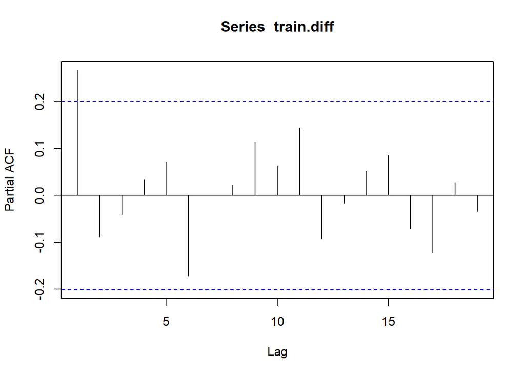

```r
pacf(train.diff)
```

Berdasarkan plot tersebut, terlihat bahwa plot PACF cenderung *cuts off* pada lag ke 1, sehingga jika plot ACF dianggap *tails of*, maka model tentatifnya adalah ARIMA(1,1,0).

Jika baik plot ACF maupun plot PACF keduanya dianggap tails of, maka model yang terbentuk adalah ARIMA(1,1,1)

#### Plot EACF

```r
eacf(train.diff)
```

```
## AR/MA
##   0 1 2 3 4 5 6 7 8 9 10 11 12 13
## 0 x o o o o o o o o o o  o  o  o
## 1 x o o o o o o o o o o  o  o  o
## 2 x x o o o o o o o o o  o  o  o
## 3 x x o o o o o o o o o  o  o  o
## 4 x x o o o o o o o o o  o  o  o
## 5 x x o x x o o o o o o  o  o  o
## 6 o o x x x o o o o o o  o  o  o
## 7 o o x o x o o o o o o  o  o  o
```

Identifikasi model menggunakan plot EACF dilakukan dengan melihat ujung segitiga pada pola segitiga nol. Dalam hal ini model tentatif yang terbentuk adalah ARIMA(0,1,1), ARIMA(0,1,2), ARIMA(1,1,1),ARIMA(1,1,2), ARIMA(2,1,2), dan ARIMA(0,1,3).

### Pendugaan Parameter Model Tentatif

#### ARIMA(0,1,1)

```r
model1.da=Arima(train.diff, order=c(0,1,1),method="ML")
summary(model1.da) #AIC=554.19
```

```
## Series: train.diff
## ARIMA(0,1,1)
##
## Coefficients:
##           ma1
##       -0.9241
## s.e.   0.0723
##
## sigma^2 = 20.19:  log likelihood = -275.09
## AIC=554.19   AICc=554.32   BIC=559.27
##
## Training set error measures:
##                       ME     RMSE      MAE     MPE     MAPE      MASE      ACF1
## Training set -0.01609533 4.446242 2.926669 100.285 238.9568 0.9137335 0.2296965
```

```r
lmtest::coeftest(model1.da) #seluruh parameter signifikan
```

```
##
## z test of coefficients:
##
##      Estimate Std. Error z value  Pr(>|z|)
## ma1 -0.924129   0.072344 -12.774 < 2.2e-16 ***
## ---
## Signif. codes:  0 '***' 0.001 '**' 0.01 '*' 0.05 '.' 0.1 ' ' 1
```

#### ARIMA(0,1,2)

```r
model2.da=Arima(train.diff, order=c(0,1,2),method="ML")
summary(model2.da) #AIC=548.63
```

```
## Series: train.diff
## ARIMA(0,1,2)
##
## Coefficients:
##           ma1      ma2
##       -0.7116  -0.2884
## s.e.   0.1052   0.0965
##
## sigma^2 = 18.4:  log likelihood = -271.32
## AIC=548.63   AICc=548.9   BIC=556.26
##
## Training set error measures:
##                      ME     RMSE      MAE      MPE    MAPE      MASE       ACF1
## Training set 0.07852966 4.221151 2.728046 41.53201 185.711 0.8517216 0.00191555
```

```r
lmtest::coeftest(model2.da) #seluruh parameter signifikan
```

```
##
## z test of coefficients:
##
##      Estimate Std. Error z value  Pr(>|z|)
## ma1 -0.711633   0.105182 -6.7657 1.327e-11 ***
## ma2 -0.288367   0.096508 -2.9880  0.002808 **
## ---
## Signif. codes:  0 '***' 0.001 '**' 0.01 '*' 0.05 '.' 0.1 ' ' 1
```

#### ARIMA(1,1,1)

```r
model3.da=Arima(train.diff, order=c(1,1,1),method="ML")
summary(model3.da) #AIC=548.97
```

```
## Series: train.diff
## ARIMA(1,1,1)
##
## Coefficients:
##          ar1      ma1
##       0.2811  -1.0000
## s.e.  0.1002   0.0384
##
## sigma^2 = 18.49:  log likelihood = -271.48
## AIC=548.97   AICc=549.23   BIC=556.6
##
## Training set error measures:
##                     ME     RMSE      MAE      MPE   MAPE      MASE       ACF1
## Training set 0.0690535 4.232096 2.705836 32.92335 193.09 0.8447874 0.01416895
```

```r
lmtest::coeftest(model3.da) #seluruh parameter signifikan
```

```
##
## z test of coefficients:
##
##      Estimate Std. Error z value  Pr(>|z|)
## ar1  0.281058   0.100164   2.806  0.005017 **
## ma1 -1.000000   0.038394 -26.046 < 2.2e-16 ***
## ---
## Signif. codes:  0 '***' 0.001 '**' 0.01 '*' 0.05 '.' 0.1 ' ' 1
```

#### ARIMA(0,1,3)

```r
model4.da<-Arima(train.diff, order=c(0,1,3),method="ML")
summary(model4.da) #AIC=550.52
```

```
## Series: train.diff
## ARIMA(0,1,3)
##
## Coefficients:
##           ma1      ma2      ma3
##       -0.6993  -0.2616  -0.0391
## s.e.   0.1125   0.1259   0.1172
##
## sigma^2 = 18.59:  log likelihood = -271.26
## AIC=550.52   AICc=550.97   BIC=560.7
##
## Training set error measures:
##                      ME     RMSE      MAE      MPE     MAPE      MASE
## Training set 0.07437707 4.220294 2.713992 32.79349 192.4022 0.8473337
##                      ACF1
## Training set -0.008255836
```

```r
lmtest::coeftest(model4.da) #seluruhhanya 1 parameter signifikan
```

```
##
## z test of coefficients:
##
##     Estimate Std. Error z value  Pr(>|z|)
## ma1 -0.69928    0.11248 -6.2172 5.062e-10 ***
## ma2 -0.26158    0.12594 -2.0771   0.03779 *
## ma3 -0.03914    0.11722 -0.3339   0.73845
## ---
## Signif. codes:  0 '***' 0.001 '**' 0.01 '*' 0.05 '.' 0.1 ' ' 1
```

#### ARIMA(1,1,2)

```r
model5.da=Arima(train.diff, order=c(1,1,2),method="ML")
summary(model5.da) #AIC=550.55
```

```
## Series: train.diff
## ARIMA(1,1,2)
##
## Coefficients:
##          ar1      ma1      ma2
##       0.0955  -0.7978  -0.2022
## s.e.  0.3219   0.3142   0.3116
##
## sigma^2 = 18.6:  log likelihood = -271.28
## AIC=550.55   AICc=551   BIC=560.73
##
## Training set error measures:
##                      ME     RMSE      MAE      MPE     MAPE      MASE
## Training set 0.07519006 4.220739 2.718123 35.92396 190.2637 0.8486236
##                      ACF1
## Training set -0.005699116
```

```r
lmtest::coeftest(model5.da) #hanya 1 parameter signifikan
```

```
##
## z test of coefficients:
##
##      Estimate Std. Error z value Pr(>|z|)
## ar1  0.095507   0.321887  0.2967  0.76669
## ma1 -0.797787   0.314236 -2.5388  0.01112 *
## ma2 -0.202157   0.311570 -0.6488  0.51645
## ---
## Signif. codes:  0 '***' 0.001 '**' 0.01 '*' 0.05 '.' 0.1 ' ' 1
```

#### ARIMA(2,1,2)

```r
model6.da=Arima(train.diff, order=c(2,1,2),method="ML")
summary(model6.da) #AIC=551.15
```

```
## Series: train.diff
## ARIMA(2,1,2)
##
## Coefficients:
##           ar1     ar2      ma1      ma2
##       -0.6425  0.2188  -0.0436  -0.9564
## s.e.   0.1389  0.1174   0.1020   0.1014
##
## sigma^2 = 18.49:  log likelihood = -270.57
## AIC=551.15   AICc=551.83   BIC=563.86
##
## Training set error measures:
##                      ME     RMSE      MAE      MPE     MAPE      MASE
## Training set 0.07566792 4.185549 2.727212 106.4742 206.7058 0.8514611
##                      ACF1
## Training set 0.0007680721
```

```r
lmtest::coeftest(model6.da) #hanya 2 parameter signifikan
```

```
##
## z test of coefficients:
##
##      Estimate Std. Error z value  Pr(>|z|)
## ar1 -0.642486   0.138903 -4.6254 3.738e-06 ***
## ar2  0.218820   0.117407  1.8638   0.06235 .
## ma1 -0.043586   0.102042 -0.4271   0.66928
## ma2 -0.956413   0.101388 -9.4332 < 2.2e-16 ***
## ---
## Signif. codes:  0 '***' 0.001 '**' 0.01 '*' 0.05 '.' 0.1 ' ' 1
```

Berdasarkan pendugaan parameter di atas, nilai AIC terkecil dimiliki oleh model ARIMA(0,1,2) dan parameter model ARIMA(0,1,2) juga seluruhnya signifikan sehingga model yang dipilih adalah model ARIMA(0,1,2).

### Analisis Sisaan

Model terbaik hasil identifikasi kemudian dicek asumsi sisaannya. Sisaan model ARIMA harus memenuhi asumsi normalitas, kebebasan sisaan, dan kehomogenan ragam. Diagnostik model dilakukan secara eksplorasi dan uji formal.

#### Eksplorasi Sisaan

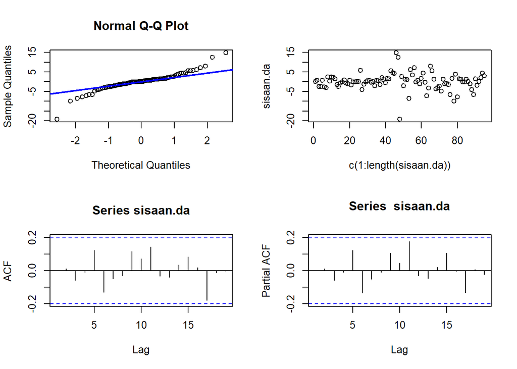

```r
#Eksplorasi
sisaan.da <- model2.da$residuals
par(mfrow=c(2,2))
qqnorm(sisaan.da)
qqline(sisaan.da, col = "blue", lwd = 2)
plot(c(1:length(sisaan.da)),sisaan.da)
acf(sisaan.da)
pacf(sisaan.da)
```

```r
par(mfrow = c(1,1))
```

Berdasarkan plot kuantil-kuantil normal, secara eksplorasi ditunjukkan sisaan tidak menyebar normal ditandai dengan titik titik yang cenderung tidak mengikuti garis $45^{\circ}$. Kemudian dapat dilihat juga lebar pita sisaan yang cenderung tidak sama menandakan bahwa sisaan memiliki ragam yang heterogen. Plot ACF dan PACF sisaan ARIMA(0,1,2) juga tidak signifikan pada 20 lag awal yang menandakan saling bebas. Kondisi ini akan diuji lebih lanjut dengan uji formal.

#### Uji Formal

```r
#1) Sisaan Menyebar Normal
ks.test(sisaan.da,"pnorm")
```

```
##
##  Exact one-sample Kolmogorov-Smirnov test
##
## data:  sisaan.da
## D = 0.23754, p-value = 3.358e-05
## alternative hypothesis: two-sided
```

Selain dengan eksplorasi, asumsi tersebut dapat diuji menggunakan uji formal. Pada tahapan ini uji formal yang digunakan untuk normalitas adalah uji Kolmogorov-Smirnov (KS). Hipotesis pada uji KS adalah sebagai berikut.

$H_0$ : Sisaan menyebar normal

$H_1$ : Sisaan tidak menyebar normal

Berdasarkan uji KS tersebut, didapat *p-value* sebesar 0.00 yang kurang dari taraf nyata 5% sehingga tolak $H_0$ dan menandakan bahwa sisaan tidak menyebar normal. Hal ini sesuai dengan hasil eksplorasi menggunakan plot kuantil-kuantil normal.

```r
#2) Sisaan saling bebas/tidak ada autokorelasi
Box.test(sisaan.da, type = "Ljung")
```

```
##
##  Box-Ljung test
##
## data:  sisaan.da
## X-squared = 0.00035971, df = 1, p-value = 0.9849
```

Selanjutnya akan dilakukan uji formal untuk kebebasan sisaan menggunakan uji Ljung-Box. Hipotesis yang digunakan adalah sebagai berikut.

$H_0$ : Sisaan saling bebas

$H_1$ : Sisaan tidak tidak saling bebas

```r
#3) Sisaan homogen
Box.test((sisaan.da)^2, type = "Ljung")
```

```
##
##  Box-Ljung test
##
## data:  (sisaan.da)^2
## X-squared = 13.402, df = 1, p-value = 0.0002513
```

Hipotesis yang digunakan untuk uji kehomogenan ragam adalah sebagai berikut.

$H_0$ : Ragam sisaan homogen

$H_1$ : Ragam sisaan tidak homogen

```r
#4) Nilai tengah sisaan sama dengan nol
t.test(sisaan.da, mu = 0, conf.level = 0.95)  #tak tolak h0 > nilai tengah sisaan sama dengan 0
```

```
##
##  One Sample t-test
##
## data:  sisaan.da
## t = 0.1804, df = 94, p-value = 0.8572
## alternative hypothesis: true mean is not equal to 0
## 95 percent confidence interval:
##  -0.7857750  0.9428343
## sample estimates:
##  mean of x
## 0.07852966
```

Terakhir, dengan uji-t, akan dicek apakah nilai tengah sisaan sama dengan nol. Hipotesis yang diujikan sebagai berikut.

$H_0$ : nilai tengah sisaan sama dengan 0

$H_1$ : nilai tengah sisaan tidak sama dengan 0

Berdasarkan uji-ttersebut, didapat *p-value* sebesar 0.8572 yang lebih besar dari taraf nyata 5% sehingga tak tolak $H_0$ dan menandakan bahwa nilai tengah sisaan sama dengan nol. Hal ini sesuai dengan eksplorasi.

### Overfitting

Tahapan selanjutnya adalah *overfitting* dilakukan dengan menaikkan orde AR(p) dan MA(q) dari model ARIMA(0,1,2) untuk melihat apakah terdapat model lain yang lebih baik dari model saat ini. Kandidat model *overfitting* adalah ARIMA(1,1,2) dan ARIMA(0,1,3).

```r
#---OVERFITTING---#
model1a.ma2=Arima(train.diff, order=c(1,1,2),method="ML")
summary(model1a.ma2) #550.55
```

```
## Series: train.diff
## ARIMA(1,1,2)
##
## Coefficients:
##          ar1      ma1      ma2
##       0.0955  -0.7978  -0.2022
## s.e.  0.3219   0.3142   0.3116
##
## sigma^2 = 18.6:  log likelihood = -271.28
## AIC=550.55   AICc=551   BIC=560.73
##
## Training set error measures:
##                      ME     RMSE      MAE      MPE     MAPE      MASE
## Training set 0.07519006 4.220739 2.718123 35.92396 190.2637 0.8486236
##                      ACF1
## Training set -0.005699116
```

```r
lmtest::coeftest(model1a.ma2) #ar1 dan ma2 tidak signifikan
```

```
##
## z test of coefficients:
##
##      Estimate Std. Error z value Pr(>|z|)
## ar1  0.095507   0.321887  0.2967  0.76669
## ma1 -0.797787   0.314236 -2.5388  0.01112 *
## ma2 -0.202157   0.311570 -0.6488  0.51645
## ---
## Signif. codes:  0 '***' 0.001 '**' 0.01 '*' 0.05 '.' 0.1 ' ' 1
```

```r
model1b.ma2=Arima(train.diff, order=c(0,1,3),method="ML")
summary(model1b.ma2) #550.52
```

```
## Series: train.diff
## ARIMA(0,1,3)
##
## Coefficients:
##           ma1      ma2      ma3
##       -0.6993  -0.2616  -0.0391
## s.e.   0.1125   0.1259   0.1172
##
## sigma^2 = 18.59:  log likelihood = -271.26
## AIC=550.52   AICc=550.97   BIC=560.7
##
## Training set error measures:
##                      ME     RMSE      MAE      MPE     MAPE      MASE
## Training set 0.07437707 4.220294 2.713992 32.79349 192.4022 0.8473337
##                      ACF1
## Training set -0.008255836
```

```r
lmtest::coeftest(model1b.ma2) #ma3 tidak signifikan
```

```
##
## z test of coefficients:
##
##     Estimate Std. Error z value  Pr(>|z|)
## ma1 -0.69928    0.11248 -6.2172 5.062e-10 ***
## ma2 -0.26158    0.12594 -2.0771   0.03779 *
## ma3 -0.03914    0.11722 -0.3339   0.73845
## ---
## Signif. codes:  0 '***' 0.001 '**' 0.01 '*' 0.05 '.' 0.1 ' ' 1
```

```r
#model yang dipilih adalah model awal, yaitu ARIMA(0,1,2)
```

Berdasarkan kedua model hasil *overfitting* di atas, model AARIMA(1,1,2) dan ARIMA(0,1,3) memiliki AIC yang lebih besar dibandingkan dengan model ARIMA(0,1,2) dan parameter kedua model ARIMA(1,1,2) dan ARIMA(0,1,3) tidak seluruhnya signifikan. Oleh karena itu, model ARIMA(0,1,2) akan tetap digunakan untuk melakukan peramalan.

### Peramalan

Peramalan dilakukan menggunakan fungsi `forecast()` . Contoh peramalan berikut ini dilakukan untuk 30 hari ke depan.

```r
#---FORECAST---#
ramalan.da <- forecast::forecast(model2.da, h = 30)
ramalan.da
```

```
##     Point Forecast     Lo 80    Hi 80     Lo 95    Hi 95
##  97      0.5645325 -4.961304 6.090369 -7.886505 9.015570
##  98     -0.2833368 -6.050191 5.483517 -9.102979 8.536305
##  99     -0.2833368 -6.050191 5.483517 -9.102979 8.536305
## 100     -0.2833368 -6.050191 5.483517 -9.102979 8.536305
## 101     -0.2833368 -6.050191 5.483517 -9.102979 8.536305
## 102     -0.2833368 -6.050191 5.483517 -9.102979 8.536305
## 103     -0.2833368 -6.050191 5.483517 -9.102979 8.536305
## 104     -0.2833368 -6.050191 5.483517 -9.102979 8.536305
## 105     -0.2833368 -6.050191 5.483517 -9.102979 8.536305
## 106     -0.2833368 -6.050191 5.483517 -9.102979 8.536305
## 107     -0.2833368 -6.050191 5.483517 -9.102979 8.536305
## 108     -0.2833368 -6.050191 5.483517 -9.102979 8.536305
## 109     -0.2833368 -6.050191 5.483517 -9.102979 8.536305
## 110     -0.2833368 -6.050191 5.483517 -9.102979 8.536305
```

[output cut: 16 more lines]

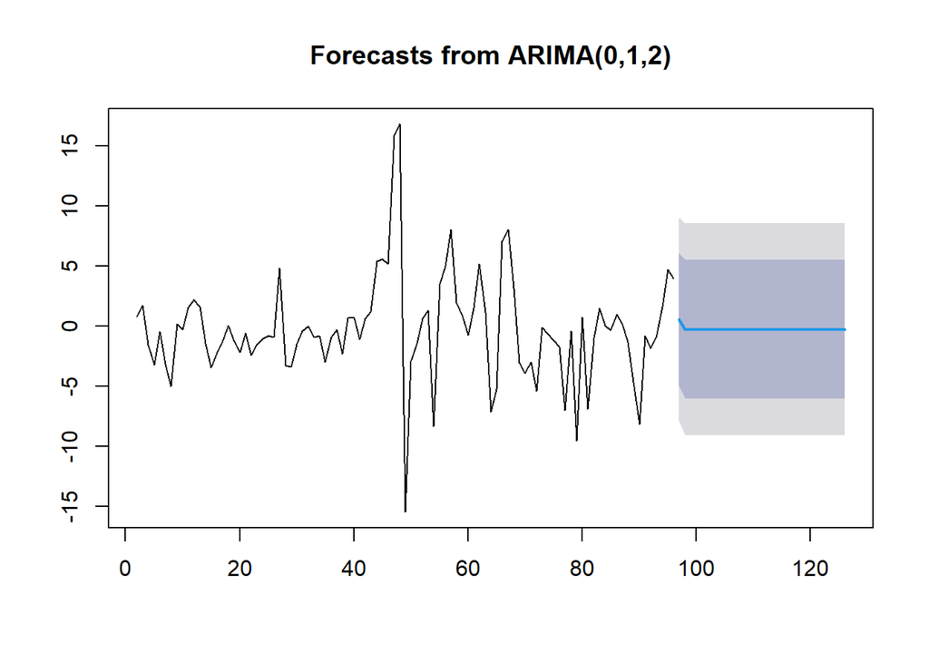

```r
data.ramalan.da <- ramalan.da$mean
plot(ramalan.da)
```

Berdasarkan hasil plot ramalan di atas, dapat dilihat bahwa ramalan ARIMA(0,1,2) cenderung stabil hingga akhir periode. Selanjutnya, dapat dicari nilai akurasi antara hasil ramalan dengan data uji sebagai berikut.

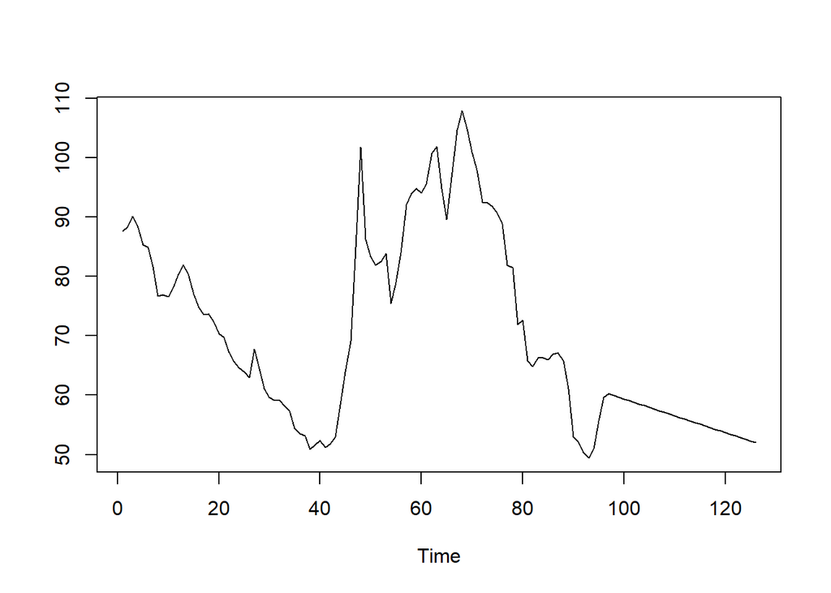

```r
pt_1 <- train.ts[96] #nilai akhir data latih
hasil.forc.Diff <- data.ramalan.da
hasil <- diffinv(hasil.forc.Diff, differences = 1) + pt_1
#has.1 sama hasilnta dengan: cumsum(c(pt_1,hasil.forc.Diff))
ts.plot(train.ts,hasil)
```

```r
perbandingan.da<-matrix(data=c(head(test.ts, n=30), hasil[-1]),
                     nrow = 30, ncol = 2)
colnames(perbandingan.da)<-c("Aktual","Hasil Forecast")
perbandingan.da
```

```
##       Aktual Hasil Forecast
##  [1,]  75.84       60.21453
##  [2,]  87.79       59.93120
##  [3,]  84.47       59.64786
##  [4,]  86.68       59.36452
##  [5,]  89.74       59.08119
##  [6,] 100.33       58.79785
##  [7,] 115.35       58.51451
##  [8,] 130.99       58.23117
##  [9,] 150.03       57.94784
## [10,] 161.63       57.66450
## [11,] 215.01       57.38116
## [12,] 159.79       57.09783
## [13,] 158.50       56.81449
## [14,] 188.38       56.53115
```

[output cut: 16 more lines]

```r
accuracy(ts(hasil[-1]), head(test.ts, n=30))
```

```
##                ME     RMSE      MAE      MPE     MAPE      ACF1 Theil's U
## Test set 154.0489 178.0456 154.0489 65.82004 65.82004 0.9075129  4.975018
```

Dari data tersebut terlihat nilai mape >10 menandakan data tersebut kurang bagus